```yaml
---
title: "Trivariate und Bivariate Dichteanalyse mit Benchden-Verteilungen"
author: "Léon Kia Faro"
date: "2024-12-05"
output:
  html_document:
    toc: yes
    toc_float: yes
    toc_depth: 3
    number_sections: true
    theme: united
    highlight: tango
---
```

# Einleitung

- Ziel: Multivariate Dichteschätzung durch Faktorisierung in univariate bedingte Dichten.
- Vergleich mit klassischen Schätzern (np, ks) und Normalizing Flows.
- Fokus:
  - *Trivariate Daten* aus Benchden-Verteilungen (für einfache Demonstration).
  - *Bivariate Daten* (Half-Moon), um komplexe Strukturen zu testen.
- Verwendung von Transformation Forests (tram) und klassischen Kernel-Methoden.
- Schrittweiser Aufbau: Erst klassische Methoden, dann Fortgeschrittenes (Normalizing Flows).

# 1. Benchden-Verteilungen

## 1.1 Verteilungsauswahl

- Benchmark-Verteilungen für Experimente.
- Erzeugung von synthetischen, teils komplexen Dichten.
- Beispiel: Skewed Bimodal, Claw, Smooth Comb.

```
## Alle verfügbaren Verteilungen aus benchden:
```

```
##  1: uniform
##  2: exponential
##  3: Maxwell
##  4: double exponential
##  5: logistic
##  6: Cauchy
##  7: extreme value
##  8: infinite peak
##  9: Pareto
## 10: symmetric Pareto
## 11: normal
## 12: lognormal
## 13: uniform scale mixture
## 14: Matterhorn
## 15: logarithmic peak
## 16: isosceles triangle
## 17: beta (2,2)
## 18: chi-square (1)
## 19: normal cubed
## 20: inverse exponential
## 21: Marronite
## 22: skewed bimodal
## 23: claw
## 24: smooth comb
## 25: caliper
## 26: trimodal uniform
## 27: sawtooth
## 28: bilogarithmic peak
```

# 2. Datengenerierung (Trivariates Beispiel)

- Generiere drei Variablen (y1,y2,y3) aus drei verschiedenen Verteilungen.
- Idee: p(y1,y2,y3) faktorisieren.
- Später: Vergleich mit np, ks und Transformation Forests.

# 3. Explorative Analyse (Trivariat)

- Univariate Statistiken
- Visualisierung wahre vs. geschätzte Dichte (Kerne)
- HDR-Analyse prüfen (Achtung: Manche Verteilungen liefern evtl. nicht mehrere HDR-Intervalle)

```
##       Verteilung   Minimum  Maximum  Mittelwert     Median        SD
## 1 skewed bimodal -2.809775 3.184044  0.37889314  0.4115223 1.1038551
## 2           claw -2.848547 3.022104 -0.04648538 -0.0469283 0.8420542
## 3    smooth comb -2.836528 2.984986 -0.05490316 -0.5923929 1.6249474
##       Schiefe Kurtosis
## 1 -0.28191622 2.344768
## 2  0.01719473 2.879791
## 3  0.28924591 1.718237
```

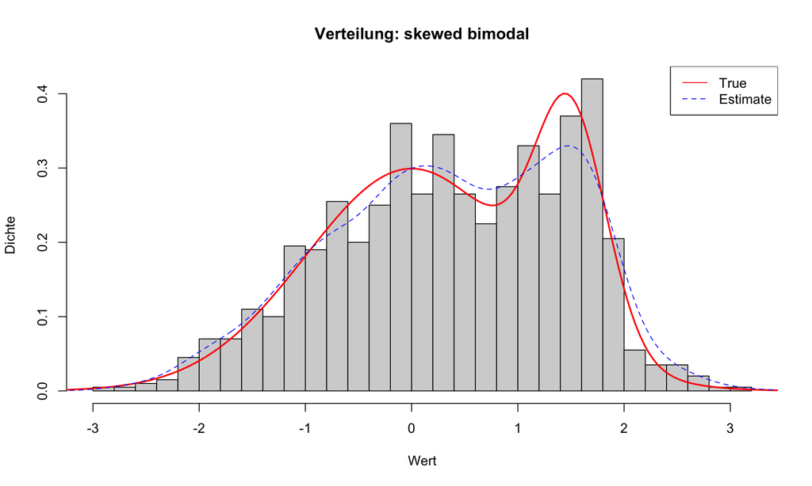

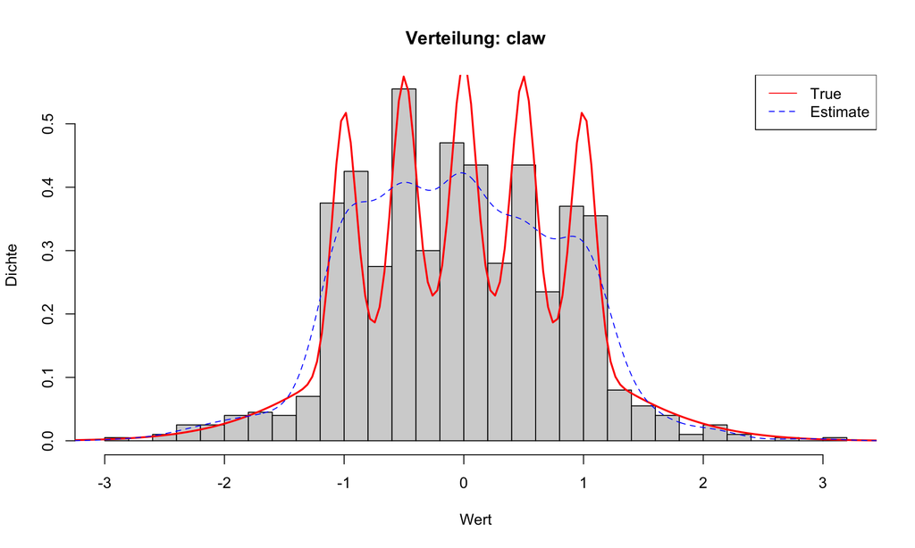

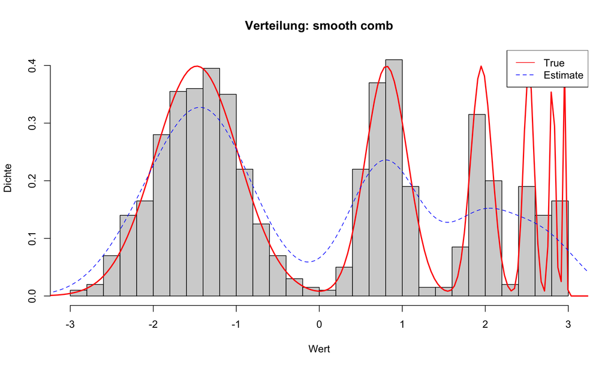

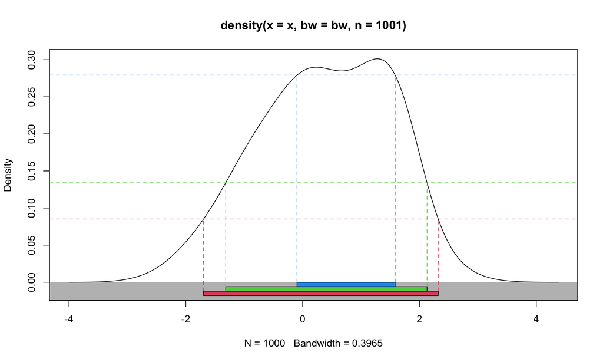

```
##            [,1]     [,2]
## 95% -1.69612188 2.321724
## 90% -1.31670037 2.130316
## 50% -0.09644027 1.583904
```

## Korrelationen (Trivariat)

- Korrelationen zwischen y1,y2,y3 untersuchen.
- 2D-Heatmap per corrplot.
- 3D-Darstellung als Höhenfeld.

```
##              y1          y2           y3
## y1  1.000000000 -0.02642850  0.009825518
## y2 -0.026428499  1.00000000 -0.055749564
## y3  0.009825518 -0.05574956  1.000000000
```

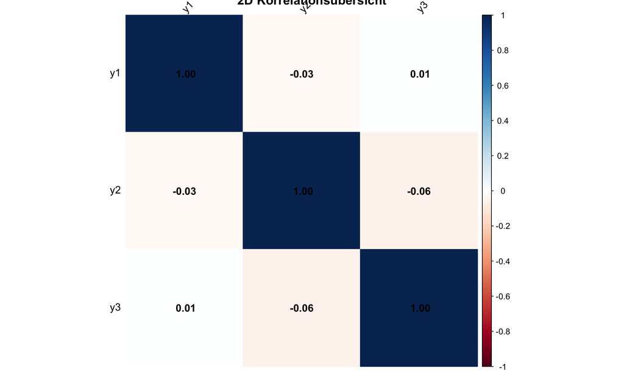

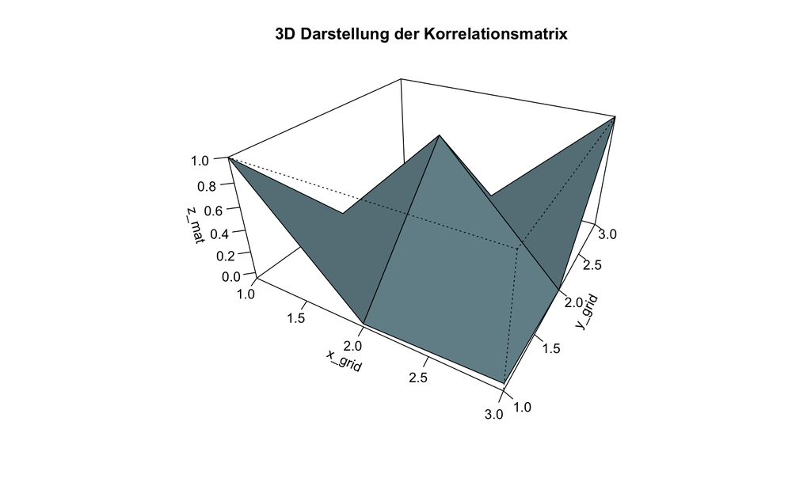

# 4. Transformation Forest Faktorisierung

- Modellierung: p(y1), p(y2|y1), p(y3|y1,y2) mit tram.
- Jede bedingte Dichte separat schätzbar.
- Anschließend Multiplikation zur Gesamtverteilung.

# 5. Vergleich Faktorisierung vs. Direkte Schätzung (np, ks)

- np-Paket: npudens für multivariate Kernel-Schätzung.
- ks-Paket: kde für multivariate Kernel-Schätzung.
- Faktorisiertes Modell: p(y1,y2,y3) = p(y1)*p(y2|y1)*p(y3|y1,y2).
- Log-Likelihood Vergleich als Performance-Indikator.

[output not shown]

```
##            Method    LogLik
## 1 Factorized (TF) -5373.085
## 2     Direct (NP) -4017.341
## 3     Direct (KS) -3976.140
```

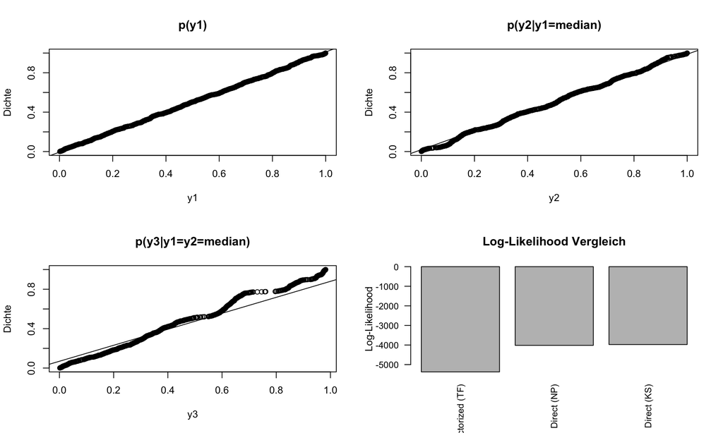

# 6. Normalizing Flows (simple)

- Nutzung von torch, einfacher Flow ohne vollständige Korrektur des Jacobians.
- Nur Demonstration.

```
##                  Method    LogLik
## 1       Factorized (TF) -5373.085
## 2           Direct (NP) -4017.341
## 3           Direct (KS) -3976.140
## 4 Normalizing Flow (NF) -2756.828
```

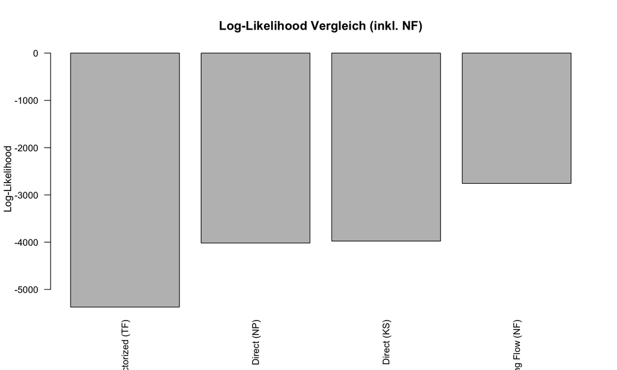

# 7. Bivariates Half-Moon Problem

[output not shown]

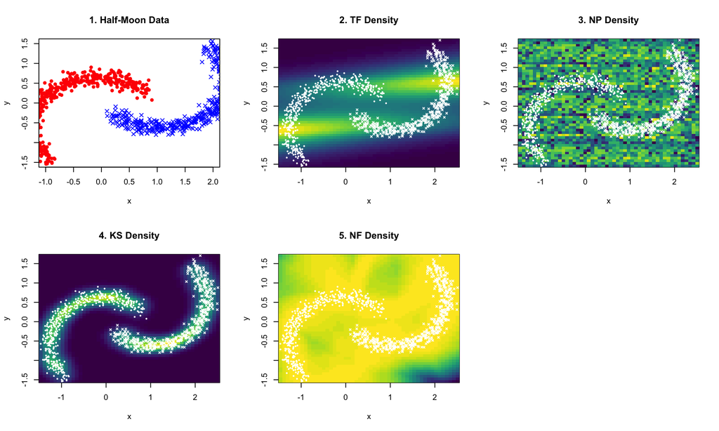

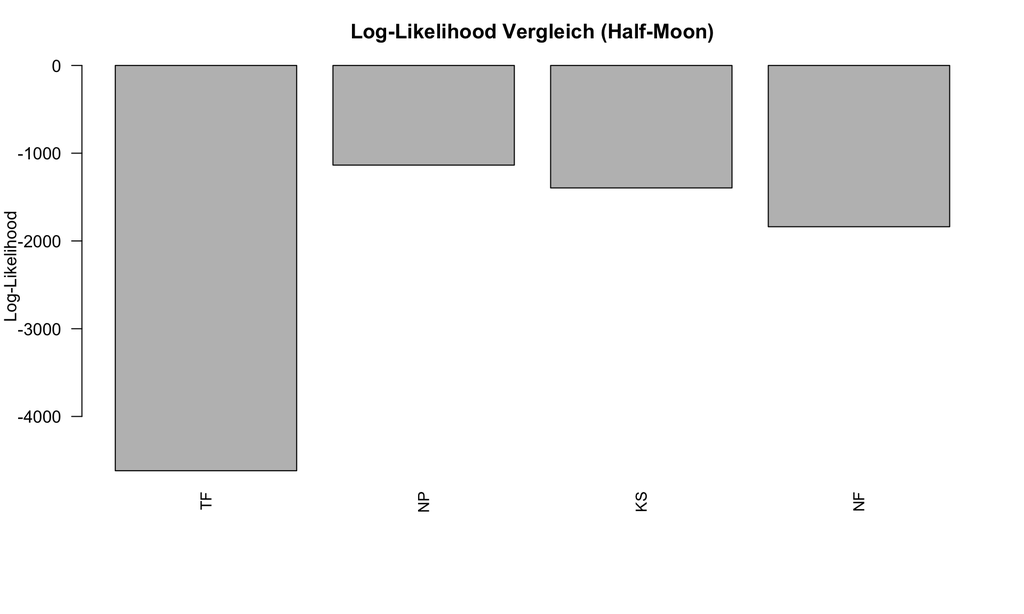

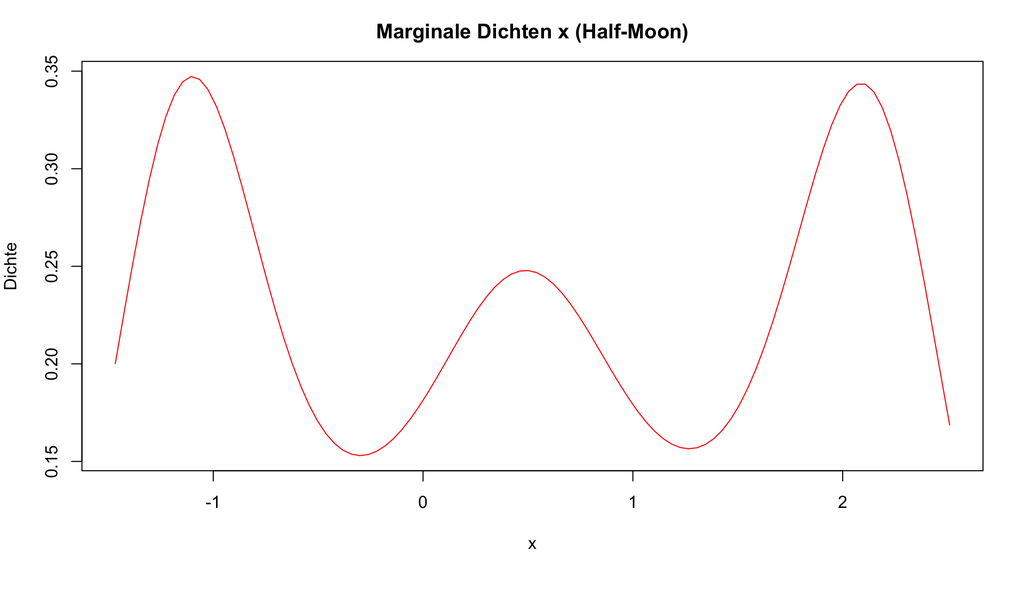

# 8. Visualisierung Half-Moon

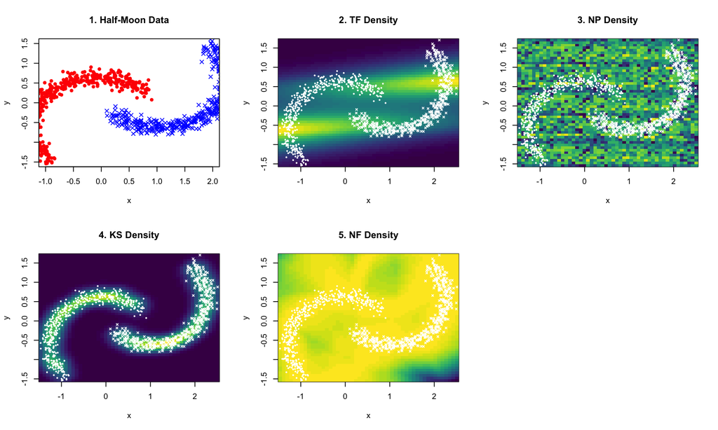

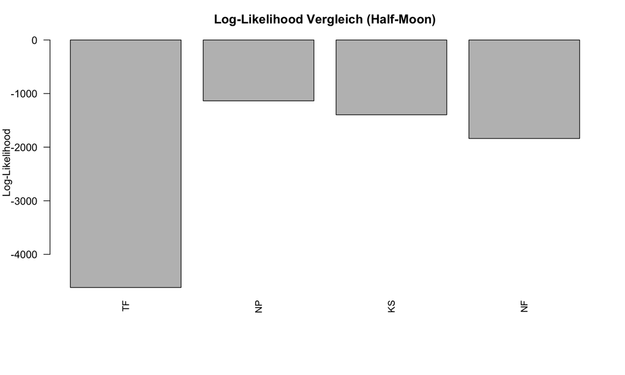

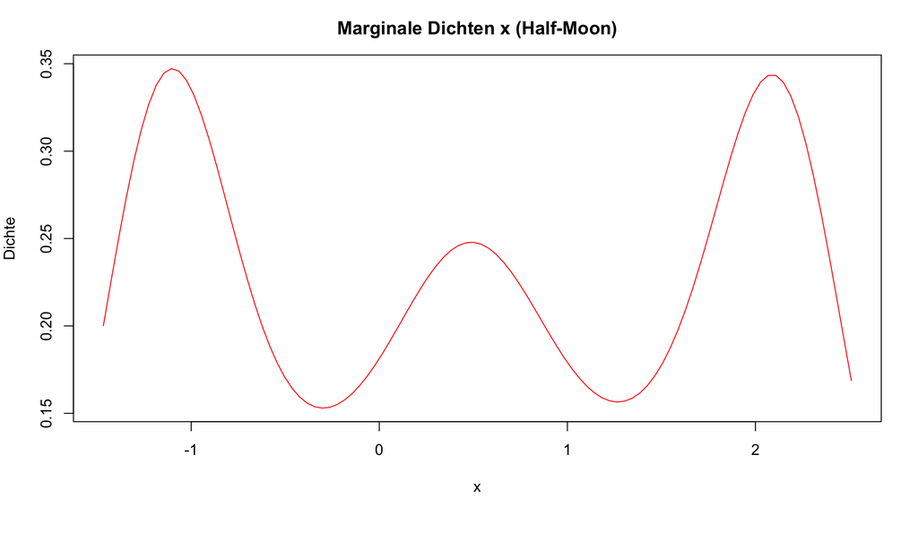